# Balancing Interpretability and Accuracy in Predictive Modeling: A Case Study on Used Car Price Estimation

The aim of this project is to predict the the price of a used vehicle on craigslist (data). The project includes the following parts:

1. data visualization
2. data preprocessing and imputation using pipelines
3. grid search on Linear Regression, Elastic Net, and LinearSVR to build a baseline linear model
4. feature engineering (e.g. imputation, encoding) and grid search on Random Forst and Gradient Boosting models and hyperparameters to find the best model
5. feature selection using permutation importance and auto feature selection (Random Forst)
6. build an explainable model that is nearly as good as the best model

The final model is a Gradient Boosting Regressor model. The test accuracy is 79%.

## Load packges and data

```python
import pandas as pd
import numpy as np
import matplotlib.pyplot as plt
%matplotlib inline
import seaborn as sns
import missingno as msno
import math

from sklearn.linear_model import LinearRegression
from sklearn.linear_model import ElasticNet
from sklearn.linear_model import Lasso
from sklearn.svm import LinearSVR
from sklearn.tree import DecisionTreeRegressor

from sklearn.model_selection import train_test_split
from sklearn.model_selection import cross_val_score
from sklearn.model_selection import GridSearchCV

from sklearn.preprocessing import OneHotEncoder
from sklearn.preprocessing import StandardScaler
from sklearn.preprocessing import OrdinalEncoder
from category_encoders import TargetEncoder
from sklearn.compose import TransformedTargetRegressor
from sklearn.compose import make_column_transformer
from sklearn.pipeline import Pipeline
from sklearn.impute import SimpleImputer
from sklearn.preprocessing import PolynomialFeatures
from sklearn.feature_selection import VarianceThreshold

from sklearn.ensemble import GradientBoostingRegressor
from sklearn.ensemble import RandomForestRegressor
from sklearn.inspection import permutation_importance
from sklearn.ensemble import GradientBoostingRegressor
from sklearn.ensemble import RandomForestRegressor
#import shap
from sklearn.feature_selection import SelectFromModel
#from sklearn.pipeline import make_pipeline
```

```python
# sampling
vehicles = pd.read_csv("./data/vehicles.csv")
n = math.ceil(vehicles.shape[0] * .03)
vehicles = vehicles.sample(n, replace=False).reset_index(drop=True)
vehicles.to_csv("./data/sample_vehicles.csv", index=False)
print(n)
```

```
12807
```

```python
# load sample data
vehicles = pd.read_csv("./data/sample_vehicles.csv")
```

## Exploratory data analysis and data cleaning

### Missing data

- Left: White indicates missing
- Right: Perfectly incorrelated is represented as 0

### Data cleaning

We conducted the following steps to clean the data and identify features:

1. **Columns**: Keep only features that we think are useful for price prediction for further inspection. Almost all data points have unique `id`, `url`, `image_url`, `VIN`, `model`, and `description`. If these features are included, a model may associate the value to the price and will not be able to generalize well. `description` also leaks target information because it contains the price in the text. We belive that the variation in `state` is more informative than in `region`. We keep the following 13 features:
   - `year`, `manufacturer`, `condition`, `cylinders`, `fuel`, `odometer`, `transmission`, `drive`, `size`, `type`, `paint_color`, `state`, `title_status` .

   And dropped the following 12 features for the above reasons and also because too much missing values (e.g. `county` has all values missing):
   - `id`, `url`, `region_url`, `VIN`, `image_url`, `description`, `county`, `lat`, `long`, `posting_date`, `region`, `model`.
2. **Rows**: Remove rows with outliers and unreasonable values. It is unreasonable for selling a (used) car for less than 1,000 or greater than 100,000; those with odometer higher than 1,000,000 are also treated as outliers. They are not a good representation of the data.
3. Convert `cylinders` (string) to numeric.

```
missing percentage:
county          1.000000
size            0.715937
cylinders       0.417428
condition       0.407902
VIN             0.377372
drive           0.307800
paint_color     0.307098
type            0.224252
manufacturer    0.041540
title_status    0.018271
long            0.015538
lat             0.015538
model           0.012337
odometer        0.010229
transmission    0.007262
fuel            0.006949
year            0.002733
description     0.000078
image_url       0.000078
posting_date    0.000078
dtype: float64
```

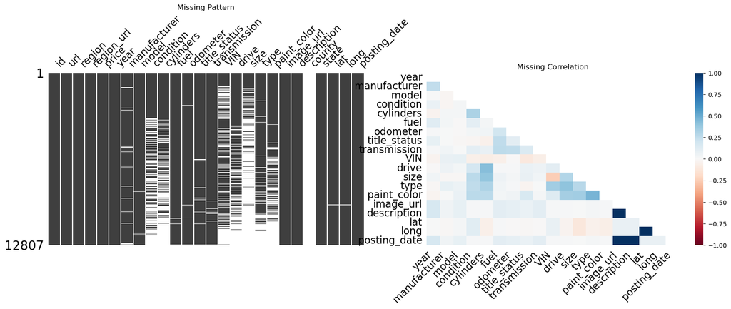

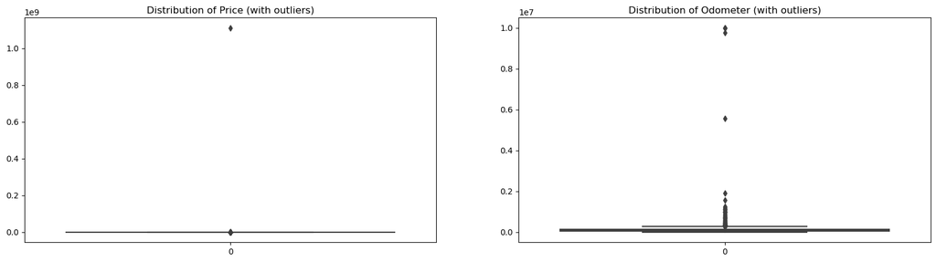

```python
# check missing
## percent missing in each feature
missing_per=(vehicles.isnull().sum()[vehicles.isnull().sum()>0]/vehicles.shape[0]).sort_values(axis='index',ascending=False)
print("missing percentage:\n{}".format(missing_per))

fig,ax = plt.subplots(1,2, figsize=(20,5))
msno.matrix(vehicles, sort="descending", sparkline=False, ax=ax[0]) # White = missing
msno.heatmap(vehicles, figsize=(10,5), ax=ax[1]) # Ideally want 0 missing correlation
ax[0].set_title('Missing Pattern');
ax[1].set_title('Missing Correlation');

# check outlier
fig,ax=plt.subplots(1,2,figsize=(20,5))
sns.boxplot(vehicles.price,ax=ax[0]);
sns.boxplot(vehicles.odometer,ax=ax[1]);
ax[0].set_title("Distribution of Price (with outliers)");
ax[1].set_title("Distribution of Odometer (with outliers)");
```

```python
# data cleaning
pd.options.mode.chained_assignment = None  # mute warnings (default='warn')

# drop missing rows and outliers
vehicles = vehicles[~((vehicles.price<1e3)|(vehicles.price>1e5)|(vehicles.odometer>1e6))]
```

### Identify features through visualization

We consider the features as:

- Continuous: `year`, `odometer`
- Categorical: `title_status`, `fuel`, `transmission`, `drive`, `type`, `manufacturer`, `paint_color`, `state`
- Ordinal: `condition`, `size`, `cylinders`

We visualize univariate relationships between each feature and the target `price`. Some interesting features are:

No patterns are observed in other features due to too few data points (e.g. manufacturer Tesla has significantly high price). However, we decide to keep most of them for further inspection because they are intuitive predictors for the selling price.

```python
categorical = ['fuel','transmission', 'drive','type',
               'manufacturer','paint_color', 'state', 'title_status']
ordinal = ['condition','size','cylinders']
continuous = ['year','odometer']
```

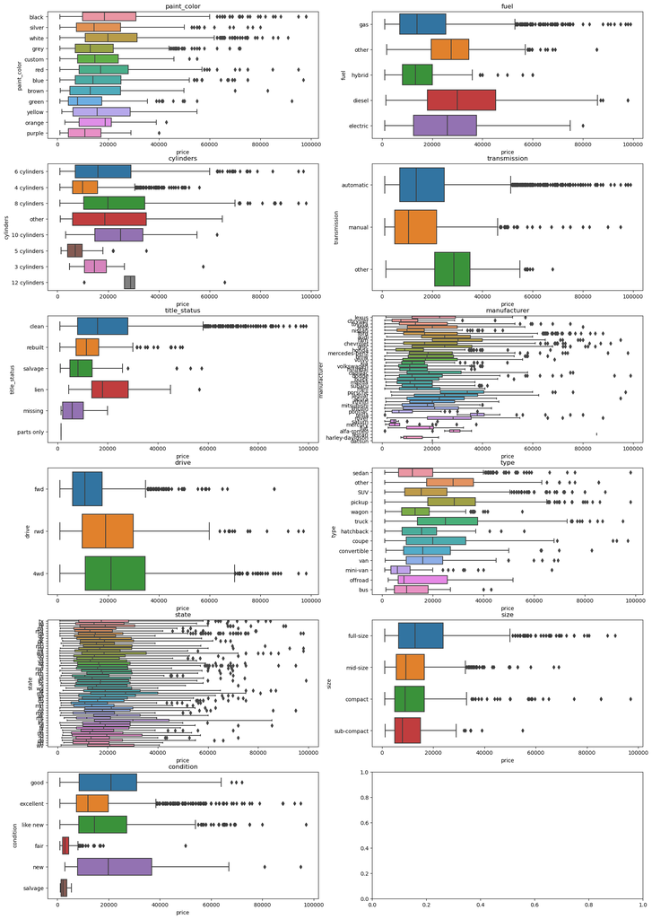

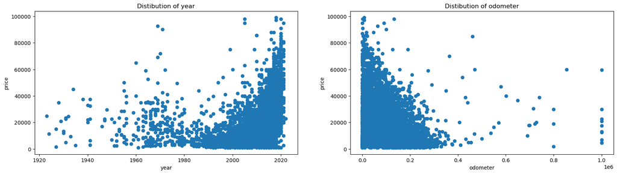

```python
# boxplot for categorical variables using seaborn
feature = list(set(categorical+ordinal))
fig,ax = plt.subplots(6,2,figsize=(20,30))
for i in range(0,6):
    if i != 5:
        for j in range(0,2):
            sns.boxplot(y=vehicles[feature[i*2+j]], x=vehicles.price, ax=ax[i,j],orient="h").set_title(feature[i*2+j])
    else:
        sns.boxplot(y=vehicles[feature[i*2]], x=vehicles.price, ax=ax[i,0],orient="h").set_title(feature[i*2])

# continuous variables
fig,ax=plt.subplots(1,2,figsize=(20,5))
for i in range(0,2):
    ax[i].scatter(vehicles[continuous[i]],vehicles.price)
    ax[i].set_xlabel(continuous[i])
    ax[i].set_ylabel('price')
    ax[i].set_title('Distibution of {}'.format(continuous[i]))
```

## Preprocessing and Baseline model

### Baseline model

We use a Linear regression model as the baseline model because it is simple to implement. For the baseline model, only the following features are being used:

- Continuous: `year`, `odometer`
- Categorical: `title_status`, `fuel`, `transmission`, `drive`, `state`, `type`
- Ordinal: `condition`, `size`, `cylinders`

`manufacturer`, `paint_color` are removed from the training data for the baseline model because they have many unique values and one-hot encoding those features will make the model have much more variable and less explainable. Using only six categorical variables allows for a reduced number of coefficients, which is good for a baseline model that serves as an initial approach to the data.

### Preprocessing

We preprocessed the data in following steps:

- drop outliers in `price` (less than 1,000 or greater than 100,000) and `odometer` (higher than 1,000,000)
- deal with missing values (imputation with mean or mode)
- standardize `odometer` (we did not standardize `year` because it does not make sense)
- target encode `state`
- one-hot encode other categprical variables （`title_status`, `fuel`, `transmission`, `drive`, `type`）

```python
from joblib import cpu_count
print(cpu_count())    # use this to check number of cores for multiprocessing in Grid Search and Random Forest

n_jobs = min(10, cpu_count())    # or None if don't want to use multiprocessing
```

```
11
```

```python
def pipe_preprocess(impute=True, continuous=[], target=[], categorical=[], ordinal=[], ord_cat=[],other_imp=[]):
    if impute:
        cat_preprocessing = Pipeline([('cat_imp',SimpleImputer(missing_values=np.nan,
                                                               strategy='most_frequent')),
                                      ('cat_pre',OneHotEncoder(handle_unknown ='ignore', drop='first'))])  # this will make the unknown category same as the first dropped category
        # check this post https://github.com/scikit-learn/scikit-learn/issues/18072
        # and https://github.com/scikit-learn/scikit-learn/pull/19041
        ord_preprocessing=Pipeline([('ord_imp',SimpleImputer(missing_values=np.nan,
                                                               strategy='most_frequent')),
                                     ('ord_pre',OrdinalEncoder(categories=ord_cat, handle_unknown = 'use_encoded_value', unknown_value = -1))])
        cont_preprocessing=Pipeline([('cont_imp',SimpleImputer(missing_values=np.nan,
                                                               strategy='mean')),
                                     ('cont_pre',StandardScaler())])
        imp_preprocessing=Pipeline([('imp',SimpleImputer(missing_values=np.nan,
                                                         strategy='most_frequent'))])
    else:
        cat_preprocessing = Pipeline([('cat_pre',OneHotEncoder(handle_unknown ='ignore'))])
        ord_preprocessing = Pipeline([('ord_pre',OrdinalEncoder(categories=ord_cat, handle_unknown = 'use_encoded_value', unknown_value = -1))])
        cont_preprocessing = Pipeline([('cont_pre',StandardScaler())])
        imp_preprocessing = None

    preprocess = make_column_transformer((cat_preprocessing,categorical),
                                         (ord_preprocessing,ordinal),
                                         (cont_preprocessing,continuous),
                                         (imp_preprocessing,other_imp),
                                         (TargetEncoder(),target),
                                         remainder='passthrough')
    return preprocess

def grid_result(param_grid, X_trainval, y_trainval, preprocess, cv=3, n_jobs=10, verbose=2):
    """
    Process and apply a grid search on X_trainval and y_trainval.
    Args:
    param_grid: dictionary of parameter settings to be grid searched on
    X_trainval, y_trainval: training and validation data
    preprocess: preprocess pipeline
    cv; # of cross-validation fold
    Return:
    grid object that is fitted on X_trainval and y_trainval
    """
    pipeline = Pipeline([('preprocess',preprocess),
                         ('regressor',LinearRegression())])

    grid = GridSearchCV(pipeline, param_grid, return_train_score=True, cv=cv, n_jobs=n_jobs, verbose=verbose)
    grid.fit(X_trainval, y_trainval)
    return grid
```

```python
continuous = ['odometer', 'year']
ordinal = ['condition','size', 'cylinders']
categorical = ['fuel','transmission','drive','title_status','type']
target = ['state']

# reorder ordinal variables for easier interpretation of the model
ord_cat = [['salvage', 'fair', 'like new', 'new', 'good', 'excellent'],
           ['sub-compact','compact', 'mid-size', 'full-size'],
           ['3 cylinders', '4 cylinders', '5 cylinders', '6 cylinders', '8 cylinders', '10 cylinders', '12 cylinders','other']]

y = vehicles.price
X = vehicles[categorical + ordinal + continuous + target]

## Set global training and test sets
global_X_trainval, global_X_test, global_y_trainval, global_y_test = train_test_split(X, y, random_state=1)

log_ols = TransformedTargetRegressor(LinearRegression(), func=np.log, inverse_func=np.exp)
param_grid=[{'regressor':[LinearRegression()]}]
preprocess = pipe_preprocess(impute=True, continuous=['odometer'], target=target, categorical=categorical, ordinal=ordinal, ord_cat=ord_cat, other_imp=['year'])
grid_cp = grid_result(param_grid, global_X_trainval, global_y_trainval, preprocess, cv=5, n_jobs=n_jobs)

print('The best model:\n {model}\nCV score: {score:.3f}'\
      .format(model=grid_cp.best_params_,score=grid_cp.best_score_))
```

```
Fitting 5 folds for each of 1 candidates, totalling 5 fits
[CV] END .......................regressor=LinearRegression(); total time=   0.0s
[CV] END .......................regressor=LinearRegression(); total time=   0.0s
[CV] END .......................regressor=LinearRegression(); total time=   0.0s
[CV] END .......................regressor=LinearRegression(); total time=   0.0s
[CV] END .......................regressor=LinearRegression(); total time=   0.0s
The best model:
 {'regressor': LinearRegression()}
CV score: 0.514
```

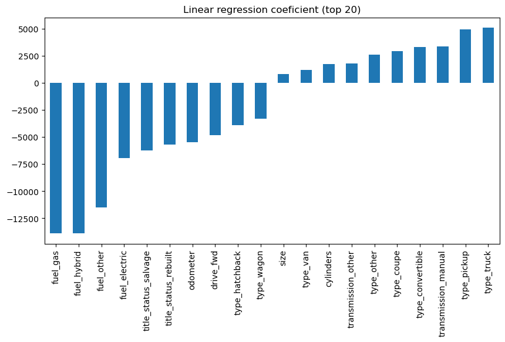

```python
col_names = grid_cp.best_estimator_.named_steps['preprocess'].transformers_[0][1].named_steps['cat_pre'].get_feature_names_out(categorical)
col_names = list(col_names) + ordinal+['odometer']+['year']+target
coef = grid_cp.best_estimator_.named_steps['regressor'].coef_
# coef = grid_cp.best_estimator_.named_steps['regressor'].regressor_.coef_

coef_plot = pd.DataFrame({"Coef":coef}, index = col_names)
coef_plot.sort_values(['Coef']).iloc[[*range(10), *range(-10, 0)]].plot.bar(figsize=(10,5), title='Linear regression coeficient (top 20)', legend=None);
```

## Feature Engineering

From the previous task, `cylinders`, `condition`, and `size` are three columns with the most missing values. At this step, we are curious whether we should

1. impute missing categorical values with the most frequent value.
2. create a new category indicating the missing data.

Based on the baseline model, we made a few modification to the features and pre-processing methods:

- transform output `price` into log form, as price seems to have a log-normal distribution
- included `manufacturer`, `paint_color` and one-hot encode them
- dealing with missing values (create an NaN category)
- rebased year to 1900 to make the value smaller
- include the interaction between ordinal variables (interaction among `cylinders`, `condition`, and `size`)

After the imputation, we also try

1. deriving `paint_color_group` from `paint_color`, which describes car colors into most common, somewhat common, and uncommon color.
2. deriving `use_type` from `type`, which categorized car types into family used and non-family used.
3. deriving a feature that describes the length of description entry

However, all of the approaches (code not shown) do no better than the current feature engineering.

```python
def pipe_preprocess(impute=True, continuous=[], target=[], categorical=[], ordinal=[], ord_cat=[], other_imp=[]):
    if impute:
        cat_preprocessing = Pipeline([('cat_imp',SimpleImputer(missing_values=np.nan, strategy='most_frequent')),
                                      ('cat_pre',OneHotEncoder(handle_unknown ='ignore', drop='first'))])  # this will make the unknown category same as the first dropped category
        # check this post https://github.com/scikit-learn/scikit-learn/issues/18072
        # and https://github.com/scikit-learn/scikit-learn/pull/19041
        ord_preprocessing=Pipeline([('ord_imp',SimpleImputer(missing_values=np.nan, strategy='most_frequent')),
                                    ('ord_pre',OrdinalEncoder(categories=ord_cat, handle_unknown = 'use_encoded_value', unknown_value = -1)),
                                    ('ord_poly',PolynomialFeatures(interaction_only=True, include_bias=False))])
        cont_preprocessing=Pipeline([('cont_imp',SimpleImputer(missing_values=np.nan, strategy='mean')),
                                     ('cont_pre',StandardScaler())])
        imp_preprocessing=Pipeline([('imp', SimpleImputer(missing_values=np.nan, strategy='most_frequent'))])
    else:
        cat_preprocessing = Pipeline([('cat_pre',OneHotEncoder(handle_unknown ='ignore'))])
        ord_preprocessing = Pipeline([('ord_pre',OrdinalEncoder(categories=ord_cat, handle_unknown = 'use_encoded_value', unknown_value = -1))])
        cont_preprocessing = Pipeline([('cont_pre',StandardScaler())])
        imp_preprocessing = None

    preprocess = make_column_transformer((cat_preprocessing,categorical),
                                         (ord_preprocessing,ordinal),
                                         (cont_preprocessing,continuous),
                                         (imp_preprocessing,other_imp),
                                         (TargetEncoder(),target),
                                         remainder='passthrough')

    return preprocess
```

```python
continuous = ['odometer', 'year']
ordinal = ['condition','size', 'cylinders']
categorical = ['fuel','transmission','drive','title_status','type',
               'manufacturer','paint_color']
target = ['state']

y = vehicles.price
X = vehicles[categorical + ordinal + continuous + target]
X['year'] = X['year'] - 1900

X[ordinal+categorical] = X[ordinal+categorical].fillna('miss')
# # reorder ordinal variables for easier interpretation of the model
# X['condition'] = X['condition'].astype('category').cat.reorder_categories(['miss','salvage', 'fair', 'like new', 'new', 'good', 'excellent'])
# X['size'] = X['size'].astype('category').cat.reorder_categories(['miss','sub-compact','compact', 'mid-size', 'full-size'])
# X['cylinders'] = X['cylinders'].astype('category').cat.reorder_categories(['miss','3 cylinders', '4 cylinders', '5 cylinders', '6 cylinders', '8 cylinders', '10 cylinders', '12 cylinders','other'])

## Set global training and test sets
global_X_trainval, global_X_test, global_y_trainval, global_y_test = train_test_split(X, y, random_state=1)
```

```python
log_ols = TransformedTargetRegressor(LinearRegression(),func=np.log,inverse_func=np.exp)
# log_en = TransformedTargetRegressor(ElasticNet(tol = 1),func=np.log,inverse_func=np.exp)
# log_svr = TransformedTargetRegressor(LinearSVR(tol = 1),func=np.log,inverse_func=np.exp)

# param_grid=[{'regressor':[log_ols]},
#             {'regressor':[log_en],
#              'regressor__regressor__alpha': np.logspace(-5,1,7),
#              'regressor__regressor__l1_ratio': [0,0.01, .1, .5, .98, 1]},
#             {'regressor':[log_svr],
#              'regressor__regressor__C':np.logspace(-5,1,7)}]
param_grid=[{'regressor':[log_ols]}]

preprocess = pipe_preprocess(impute=True, continuous=continuous, target=target,
                             categorical=categorical, ordinal=ordinal, ord_cat=ord_cat)
grid_cp = grid_result(param_grid, global_X_trainval, global_y_trainval, preprocess, cv=5, n_jobs=n_jobs)

print('The best model:\n {model}\nCV score: {score:.3f}'\
      .format(model=grid_cp.best_params_,score=grid_cp.best_score_))
```

```
Fitting 5 folds for each of 1 candidates, totalling 5 fits
[CV] END regressor=TransformedTargetRegressor(func=<ufunc 'log'>, inverse_func=<ufunc 'exp'>,
                           regressor=LinearRegression()); total time=   0.0s
[CV] END regressor=TransformedTargetRegressor(func=<ufunc 'log'>, inverse_func=<ufunc 'exp'>,
                           regressor=LinearRegression()); total time=   0.0s
```

```
[CV] END regressor=TransformedTargetRegressor(func=<ufunc 'log'>, inverse_func=<ufunc 'exp'>,
                           regressor=LinearRegression()); total time=   0.0s
[CV] END regressor=TransformedTargetRegressor(func=<ufunc 'log'>, inverse_func=<ufunc 'exp'>,
                           regressor=LinearRegression()); total time=   0.0s
[CV] END regressor=TransformedTargetRegressor(func=<ufunc 'log'>, inverse_func=<ufunc 'exp'>,
                           regressor=LinearRegression()); total time=   0.0s
The best model:
 {'regressor': TransformedTargetRegressor(func=<ufunc 'log'>, inverse_func=<ufunc 'exp'>,
                           regressor=LinearRegression())}
CV score: 0.569
```

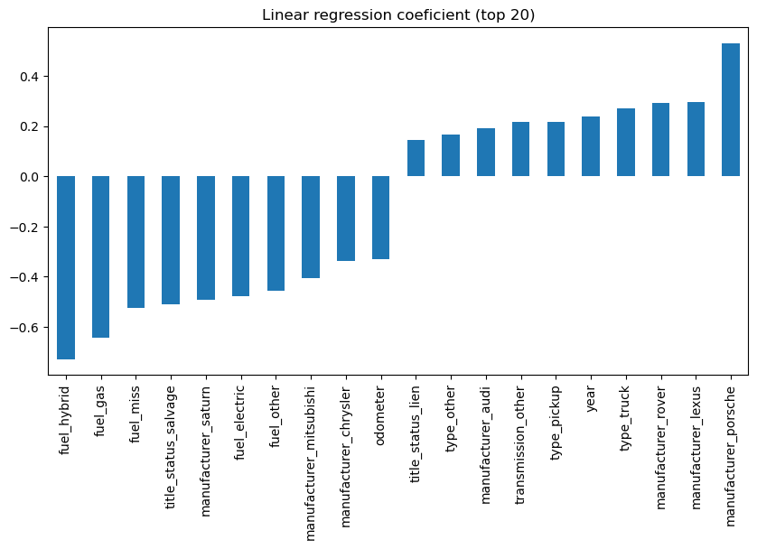

```python
col_names = list(grid_cp.best_estimator_.named_steps['preprocess'].transformers_[0][1].named_steps['cat_pre'].get_feature_names_out(categorical))+\
            list(grid_cp.best_estimator_.named_steps['preprocess'].transformers_[1][1].named_steps['ord_poly'].get_feature_names_out(ordinal))+\
            ['odometer']+['year']+target
# coef = grid_cp.best_estimator_.named_steps['regressor'].coef_
coef = grid_cp.best_estimator_.named_steps['regressor'].regressor_.coef_

coef_plot = pd.DataFrame({"Coef":coef}, index = col_names)
coef_plot.sort_values(['Coef']).iloc[[*range(10), *range(-10, 0)]].plot.bar(figsize=(10,5), title='Linear regression coeficient (top 20)', legend=None);
```

## Grid Search with Random Forest and Gradient Boosting

In addition to Linear Regression, we train models with

- GradientBoosting and
- Random Forest

and conducted Grid Search on the hyperparameters (code shown below).

The $R^2$ of validation set improves from 0.57 to 0.79 when we use gradient boosting with the following hyperparameters

- loss = `huber`
- learning_rate = `0.1`
- max_depth = `9`

The test score is 0.791.

We further tried to introduce new features: "**length of description**" and "**spaces in description**" into the model, but they did not significantly improves the model performance. (Code not shown).

```python
import warnings
warnings.filterwarnings("ignore")

log_gbr=TransformedTargetRegressor(GradientBoostingRegressor(warm_start = True),func=np.log,inverse_func=np.exp)
log_rfr=TransformedTargetRegressor(RandomForestRegressor(warm_start = True),func=np.log,inverse_func=np.exp)

param_grid=[{'regressor':[log_gbr],
             'regressor__regressor__loss': ['squared_error', 'absolute_error', 'huber'],
             'regressor__regressor__learning_rate': [0.001, 0.01, 0.1, 0.5],
             'regressor__regressor__max_depth': [7,9,11]},
            {'regressor':[log_rfr],
             'regressor__regressor__max_depth': [7,9,11],
             'regressor__regressor__n_estimators': [100, 150, 200]}]

best_grid = grid_result(param_grid, global_X_trainval, global_y_trainval, preprocess, cv=5, n_jobs=n_jobs)
```

```
Fitting 5 folds for each of 45 candidates, totalling 225 fits
```

[output not shown]

[output not shown]

[output not shown]

[output not shown]

[output not shown]

[output not shown]

[output not shown]

[output not shown]

[output not shown]

[output not shown]

[output not shown]

[output not shown]

[output not shown]

[output not shown]

[output not shown]

[output not shown]

[output not shown]

[output not shown]